# FIN_654_WK4_R

Kendra Osburn

7/28/2019

# UNIT 4 | Market Risk

## 4.1: Readings

## 4.2: Exercise: Imagine This

Video: 5min

### EXERCISE

Suppose you are in charge of the project to manage the contracting for electricity and steel at your specialty steel company. Your company and industry have traditionally used tolling agreements to manage the steel-power spread, both from power input and steel output points of view.

1. Look up a tolling agreement and summarize its main components
2. What are the input and output decisions in this kind of agreement?

INPUT: Electrons OUTPUT: Steel Transformation rate at an agreed cost Things we need to know for this agreement:

1. Prices of Power and Steel
2. Cost of transformation

NOTES: – All of the agreed to things are called “Real Options”

#### OUTCOMES THIS WEEK:

1. Measure risk using historical and parametric appraches
2. Interpret results relative to business decisions
3. Visualize Market Risk

#### We will use:

– fitdistr() – Moments (? MOM)

## 4.3: Exercise: History Speaks

Video: 9 min

### EXERCISE

Now let’s really explore this data. The library psych has a prefabricated scatter plot???histogram matrix we can use. With this composite plot, we examine historical relationships between the two risk factors as well as the shape of the risk factors themselves. We can also use this device to look at dependent simulations. After the scatter plots, we then look at the time series plots of the two factors.

```r
# Examine the two price series using scatter plots and histograms
data.all <- read.csv("data/eurostock.csv", stringsAsFactors = FALSE)
data.all2 <- read.csv("data/FIN_654_stocks.csv", stringsAsFactors = FALSE)
str(data.all)
```

```
## 'data.frame':    6147 obs. of  24 variables:
##  $ X              : chr  "1973-01-01" "1973-01-02" "1973-01-03" "1973-01-04" ...
##  $ ALLIANZ.HLDG.  : num  156 156 161 162 164 ...
##  $ COMMERZBANK    : num  147 147 149 152 152 ...
##  $ DRESDNER.BANK  : num  18.4 18.4 18.8 18.9 18.9 ...
##  $ BMW            : num  104 109 110 111 109 ...
##  $ SCHERING       : num  36.9 37.4 37.8 37.9 37.4 ...
##  $ BASF           : num  15 15.4 15.6 15.8 15.8 ...
##  $ BAYER          : num  12.2 11.9 12.1 12.7 12.7 ...
##  $ BAYERISCHE.VBK.: num  23.5 22.9 23.4 23.7 23.9 ...
##  $ BAYER.HYPBK.   : num  23.4 23.2 23.3 23.5 23.4 ...
##  $ DEGUSSA        : num  203 207 208 210 214 ...
##  $ DEUTSCHE.BANK  : num  22.3 22.5 22.9 23 23.3 ...
##  $ CONTINENTAL    : num  8.54 8.83 8.78 8.83 8.73 8.82 8.74 8.73 8.74 8.74 ...
##  $ VOLKSWAGEN     : num  134 140 145 144 140 ...
##  $ DAIMLER.BENZ   : num  17 17.6 17.8 17.8 17.7 ...
##  $ HOECHST        : num  13.8 13.8 14.2 14.3 14.2 ...
##  $ SIEMENS        : num  20.8 21.1 21.3 21.4 21.5 ...
##  $ KARSTADT       : num  360 360 362 369 368 ...
##  $ LINDE          : num  136 137 140 142 144 ...
##  $ THYSSEN        : num  67.5 68.4 67.5 71.6 71.2 ...
##  $ MANNESMANN     : num  85 86.5 87.8 88.7 88.6 ...
##  $ MAN            : num  118 119 125 125 127 ...
##  $ RWE            : num  11.7 11.9 12 11.9 12 ...
##  $ INDEX          : num  536 545 552 556 557 ...
```

```r
row.names <- data.all$X
date <- as.Date(row.names)
rownames(data.all) <- date
start.date <- "1975-06-02"
end.date <- "1990-12-30"

price <- data.all[start.date <= date & date <= end.date, c("RWE", "THYSSEN")]
# don't worry about dparse but that is a ZERO
if(!is.matrix(price)) price <- rbind(price, deparse.level = 0L)
str(price)
```

```
## 'data.frame':    4065 obs. of  2 variables:
##  $ RWE    : num  8.96 9.2 9.16 9.2 9.36 9.24 9.12 9.08 9.04 8.99 ...
##  $ THYSSEN: num  69.8 70.8 69.8 68.9 68.8 ...
```

```r
head(price)
```

```
##             RWE THYSSEN
## 1975-06-02 8.96   69.82
## 1975-06-03 9.20   70.77
## 1975-06-04 9.16   69.82
## 1975-06-05 9.20   68.88
## 1975-06-06 9.36   68.79
## 1975-06-09 9.24   67.94
```

```r
## GETS HEAD AND TAIL!!
(end.idx <- dim(price)[1])
```

```
## [1] 4065
```

```r
(price.2 <- rbind(price[1:5,], price[(end.idx - 4):end.idx,]))
```

```
##              RWE THYSSEN
## 1975-06-02  8.96   69.82
## 1975-06-03  9.20   70.77
## 1975-06-04  9.16   69.82
## 1975-06-05  9.20   68.88
## 1975-06-06  9.36   68.79
## 1990-12-24 36.36  187.50
## 1990-12-25 36.36  187.50
## 1990-12-26 36.36  187.50
## 1990-12-27 36.28  186.50
## 1990-12-28 35.75  184.50
```

```r
# TODO
# function(startdate, enddate, dataset){}
library(psych)
```

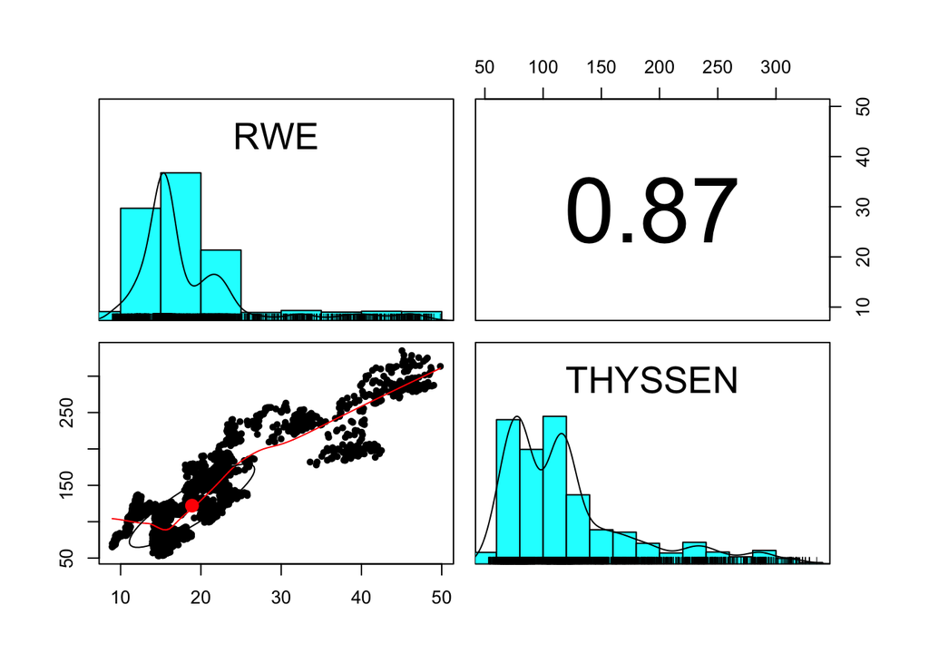

```r
# Right panel is correlation %
pairs.panels(price)
```

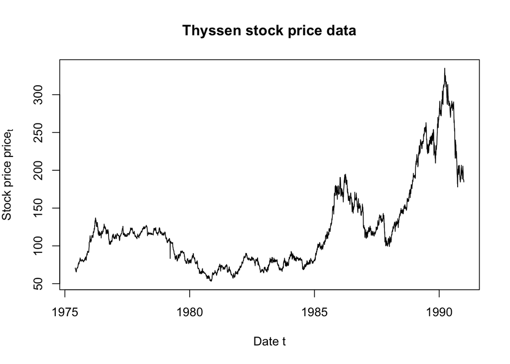

```r
price.rownames <- rownames(price)
plot(as.Date(price.rownames), price[,"THYSSEN"], type="l",
     main="Thyssen stock price data",
     xlab="Date t",
     ylab=expression(Stock~price~price[t]))
```

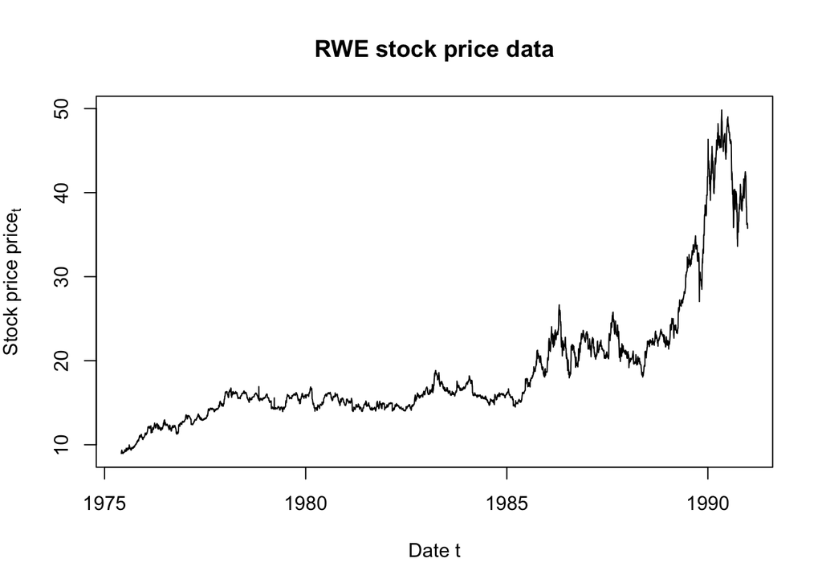

```r
plot(as.Date(price.rownames), price[,"RWE"], type="l",
     main="RWE stock price data",
     xlab="Date t",
     ylab=expression(Stock~price~price[t]))
```

```r
## REPLICATING WITH BMW AND VOLKSWAGEN
price <- data.all[start.date <= date & date <= end.date, c("BMW", "VOLKSWAGEN")]
# don't worry about dparse but that is a ZERO
if(!is.matrix(price)) price <- rbind(price, deparse.level = 0L)
str(price)
```

```
## 'data.frame':    4065 obs. of  2 variables:
##  $ BMW       : num  97.6 102.4 101 100.3 102.1 ...
##  $ VOLKSWAGEN: num  83.3 89.7 86.8 86.3 87.6 ...
```

```r
head(price)
```

```
##               BMW VOLKSWAGEN
## 1975-06-02  97.63      83.29
## 1975-06-03 102.37      89.65
## 1975-06-04 101.02      86.80
## 1975-06-05 100.34      86.30
## 1975-06-06 102.14      87.56
## 1975-06-09 100.79      86.30
```

```r
## GETS HEAD AND TAIL!!
(end.idx <- dim(price)[1])
```

```
## [1] 4065
```

```r
(price.2 <- rbind(price[1:5,], price[(end.idx - 4):end.idx,]))
```

```
##               BMW VOLKSWAGEN
## 1975-06-02  97.63      83.29
## 1975-06-03 102.37      89.65
## 1975-06-04 101.02      86.80
## 1975-06-05 100.34      86.30
## 1975-06-06 102.14      87.56
## 1990-12-24 342.51     337.00
## 1990-12-25 342.51     337.00
## 1990-12-26 342.51     337.00
## 1990-12-27 335.65     337.00
## 1990-12-28 337.36     336.90
```

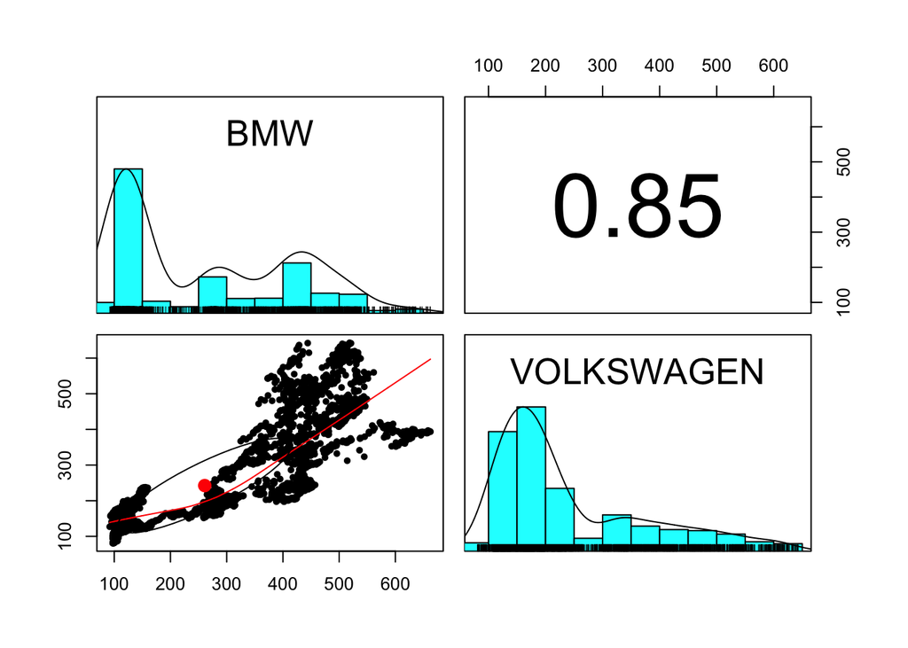

```r
# TODO
# function(startdate, enddate, dataset){}
library(psych)
# Right panel is correlation %
pairs.panels(price)
```

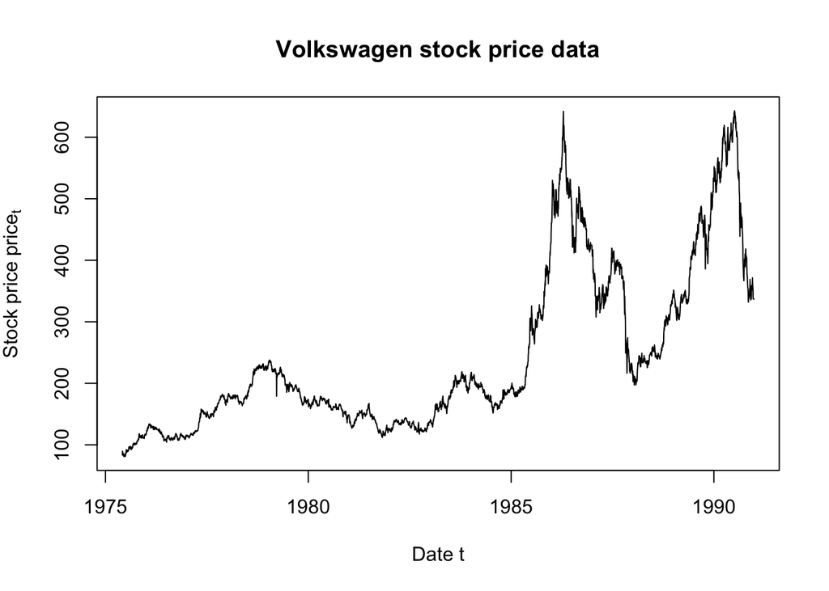

```r
price.rownames <- rownames(price)
plot(as.Date(price.rownames), price[,"VOLKSWAGEN"], type="l",
     main="Volkswagen stock price data",
     xlab="Date t",
     ylab=expression(Stock~price~price[t]))
```

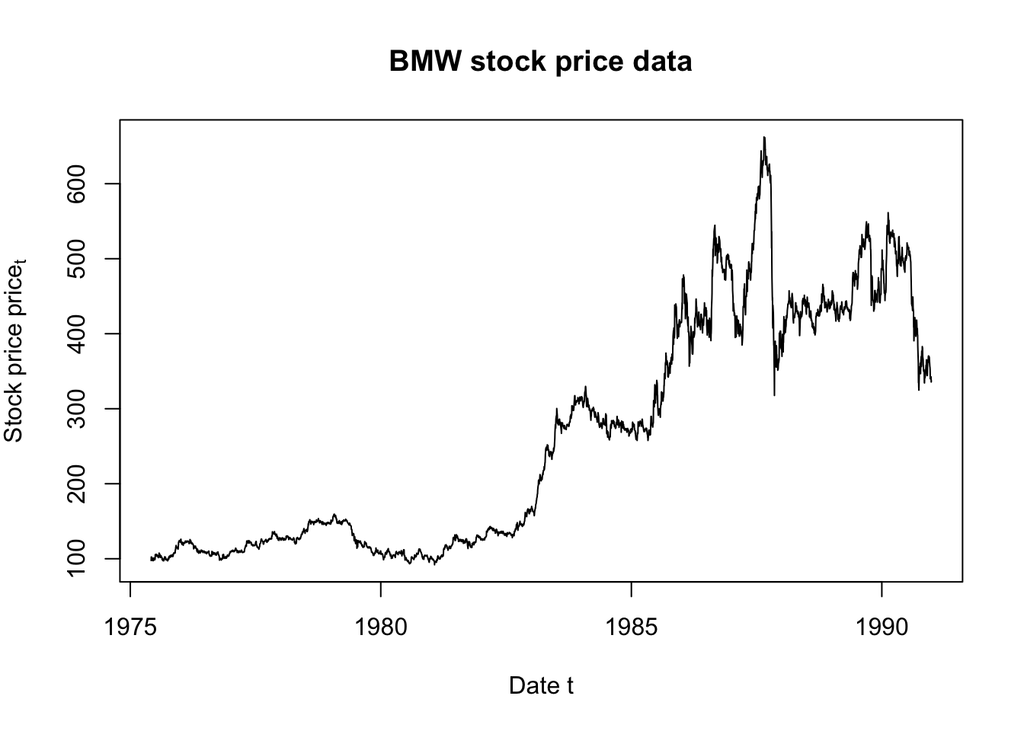

```r
plot(as.Date(price.rownames), price[,"BMW"], type="l",
     main="BMW stock price data",
     xlab="Date t",
     ylab=expression(Stock~price~price[t]))
```

## 4.4: Exercise: Now to the Matters at Hand

Weights are defined as the value of the positions in each risk factor INPUT: Electricity OUTPUT: Steel Forming the margin Margin = price(of steel) x tons - price(of power) x [rateMWh/ x tons] The last term is the power to steel transformation rate that converts prices $ per MWh to $ per ton

```r
return.range <- range(return.series <- apply(log(price), 2, diff ))
return.range
```

```
## [1] -0.1812716  0.1547891
```

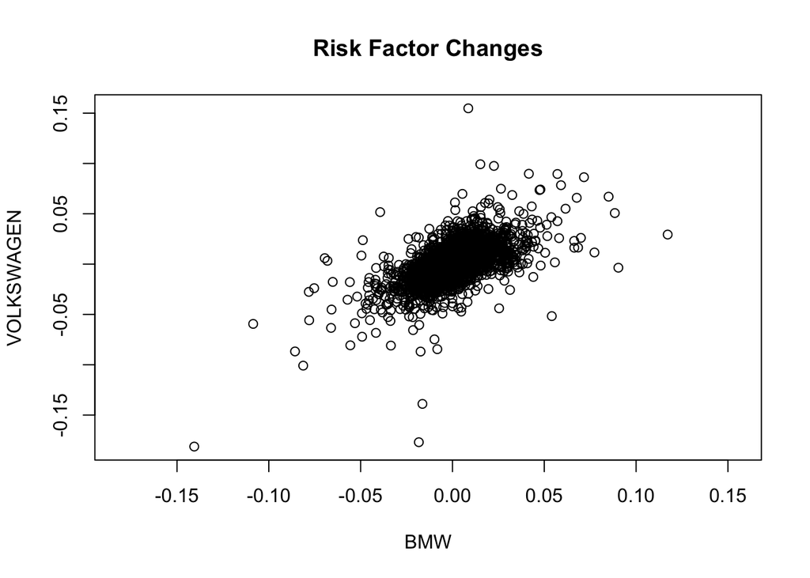

```r
plot(return.series, xlim = return.range,
     ylim = return.range, main = "Risk Factor Changes")
```

```r
price.last <- as.numeric(tail(price, n=1))
position.rf <- c(-30, 10)
w <- position.rf * price.last
weights.rf <- matrix(w, nrow = nrow(return.series), ncol = ncol(return.series))
loss.rf <- -rowSums(expm1(return.series)* weights.rf)
summary(loss.rf)
```

```
##       Min.    1st Qu.     Median       Mean    3rd Qu.       Max.
## -1824.9430   -80.4541     0.0000     0.9274    70.9466  1664.0867
```

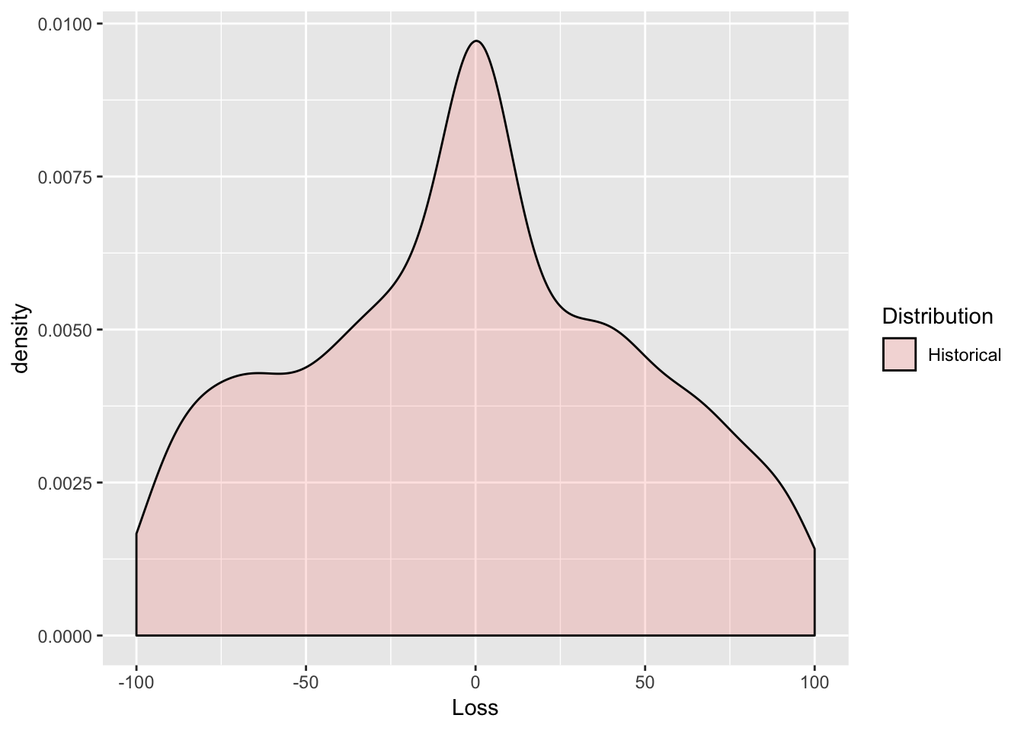

```r
loss.rf.df <- data.frame(Loss = loss.rf, Distribution = rep("Historical", each = length(loss.rf)))
library(ggplot2)
ggplot(loss.rf.df, aes(x = Loss, fill = Distribution)) + geom_density(alpha = 0.2) + xlim(-100,100)
```

Video: 17 min

NOTES: Calculating: – Value at Risk – Expected SHortfall

## 4.5: Exercise: Carl Freidrich Gauss, I presume

## 4.6: Exercise: Let’s Go to Extremes

## 4.7: All Together Now

## 4.8: The Wrap

- Filtering
- Data Frames
- Simulation
- Math to R translation
- Graphics
- Normal and GPD distributions
- VaR and ES (Value at Risk, Expected Shortfall)
- Loss distributions and mean over loss

## QUESTIONS:

- ELI-lemonade stand: Value at Risk, Expected Shortfall
- 4.4 Now to the Matter at Hand POSTITIONS: Negative position (short position) in electricity and Positive position for steel (-30, 10) (how we’re going to weight)

### Pivot Tables

1a. Read CSV *The str() function allows us to see all of the objects in CreditCard* NOTE: If it’s in a data frame, we can subset it!